# Extensiones del Modelo Regresión Lineal Múltiple

Juan Barriola y Sofía Perini

23 de Octubre de 2021

```r
library(tidyverse)
library(tidymodels)
library(gridExtra)
```

## Dataset

Vamos a trabajar con el subconjunto de datos que se utilizó en la clase anterior, precio de venta en dólares de las propiedades en Capital Federal reportadas por la empresa [Properati Argentina](https://www.properati.com.ar/).

```r
# Levantamos Dataset
datos_properati <- read.csv("../clase 6/properati_preprocesado.csv")
```

### Repaso Diagnóstico del Modelo Lineal previo

**Diagnóstico para el Modelo Varias con Barrios**

El diagnóstico del modelo consiste en utilizar técnicas para validar el cumplimiento (o no) de los supuestos del modelo lineal. Recordemos que estos supuestos se puede resumir en:

$ε_i ∼ N(0,σ^2)$ independientes entre sí.

- A través del análisis gráfico se pudo notar que los residuos parecen tener algún tipo de estructura: se distingue un incremento de la varianza al aumentar el valor predicho. Esto podría indicar que el **supuesto de homogeneidad de varianzas** (homocedasticidad) no se satisface. La variabilidad que se observa frente a precios más altos puede tener que ver con que existen diferencias significativas de precios según el tipo de propiedad o el barrio.
- El QQplot permitió verificar que los puntos se alejan un poco de la diagonal hacia los extremos, lo que puede indicar que los residuos no tienen una **distribución normal** y, por lo tanto, los errores tampoco.
- Es decir, que se puede detectar cierto patrón en los residuos y, por ende, existe margen de mejora del modelo.

## Modelo con transformación logarítmica de Y

Para resolver el hecho de que la varianza no sea constante se puede emplear una transformación estabilizadora de la varianza para transformar a las Y, ya que el reemplazo de $Y$ por $Y_{transformada}$ puede inducir varianza constante en la escala transformada.

La forma más común de mejorar un modelo es transformar una o más variables, generalmente usando una transformación logarítmica dado que permite modificar la forma de su distribución. Es por ello, que se efectúa un nuevo modelo empleando dichas transformaciones y se analizan sus resultados.

## Modelo log

Entonces, nuestro objetivo será ajustar e interpretar un modelo de regresión lineal múltiple que buscan explicar el precio de venta en dólares de dichas propiedades pero distinto a los que vimos hasta ahora:

$$log(price) = \beta_0 + \beta_{r}log(rooms) + \beta_{b}log(bathrooms) + \beta_{sc}log(surface\_covered) + \beta_{pt}property\_type + \beta_{l3}l3 + \beta_{su}surface\_uncovered$$

### Creamos nuevas variables

- Creamos una nueva variable de superficie descubierta para captar la informacion adicional de superficie total sin entrar en conflicto con superficie cubierta, por su alta colinealidad.
- Creamos nuevas variables transformadas con log.

```r
# creamos nueva variable de superficie descubierta
datos_properati = datos_properati %>%
  mutate(surface_uncovered = surface_total - surface_covered)
# creamos variables log
datos_properati = datos_properati %>%
  mutate(log.price = log(price), log.rooms = log(rooms), log.bathrooms = log(bathrooms), log.surf_cov = log(surface_covered))
head(datos_properati)
```

|  | id | l3 | rooms | bathrooms | surface_total | surface_covered | price | property_type | precio_en_miles | surface_uncovered | log.price | log.rooms | log.bathrooms | log.surf_cov |
| --- | --- | --- | --- | --- | --- | --- | --- | --- | --- | --- | --- | --- | --- | --- |
| 1 | AfdcsqUSelai1ofCAq2B0Q== | Velez Sarsfield | 3 | 2 | 95 | 69 | 199900 | Casa | 200 | 26 | 12.20557 | 1.098612 | 0.6931472 | 4.234107 |
| 2 | ESzybdH7YU2uIU1/kHtRGw== | Nuñez | 1 | 1 | 44 | 38 | 147000 | Departamento | 147 | 6 | 11.89819 | 0.000000 | 0.0000000 | 3.637586 |
| 3 | r22OfzZ3kXooSPoE5HMuZQ== | Almagro | 1 | 1 | 40 | 37 | 92294 | Departamento | 92 | 3 | 11.43273 | 0.000000 | 0.0000000 | 3.610918 |
| 4 | atZQXVtyfG7+OiX6gYY3lA== | Almagro | 1 | 1 | 49 | 44 | 115000 | Departamento | 115 | 5 | 11.65269 | 0.000000 | 0.0000000 | 3.784190 |
| 5 | R7IsTtVsxPCiRbIHMaWGxA== | Almagro | 1 | 1 | 40 | 37 | 77000 | Departamento | 77 | 3 | 11.25156 | 0.000000 | 0.0000000 | 3.610918 |
| 6 | Tur/v/qE41UBT83NM/bI7w== | Almagro | 1 | 1 | 40 | 37 | 88900 | Departamento | 89 | 3 | 11.39527 | 0.000000 | 0.0000000 | 3.610918 |

```r
summary(datos_properati)
```

```
      id                 l3                rooms          bathrooms
 Length:49835       Length:49835       Min.   : 1.000   Min.   : 1.000
 Class :character   Class :character   1st Qu.: 2.000   1st Qu.: 1.000
 Mode  :character   Mode  :character   Median : 3.000   Median : 1.000
                                       Mean   : 2.767   Mean   : 1.475
                                       3rd Qu.: 4.000   3rd Qu.: 2.000
                                       Max.   :10.000   Max.   :14.000
 surface_total     surface_covered       price         property_type
 Min.   :  12.00   Min.   :   2.00   Min.   :  12000   Length:49835
 1st Qu.:  45.00   1st Qu.:  40.00   1st Qu.: 118000   Class :character
 Median :  65.00   Median :  58.00   Median : 169000   Mode  :character
 Mean   :  88.61   Mean   :  76.37   Mean   : 234457
 3rd Qu.: 103.00   3rd Qu.:  89.00   3rd Qu.: 268000
 Max.   :2000.00   Max.   :1400.00   Max.   :5700000
 precio_en_miles  surface_uncovered   log.price        log.rooms
 Min.   :  12.0   Min.   :  0.00    Min.   : 9.393   Min.   :0.0000
 1st Qu.: 118.0   1st Qu.:  0.00    1st Qu.:11.678   1st Qu.:0.6931
 Median : 169.0   Median :  5.00    Median :12.038   Median :1.0986
 Mean   : 234.5   Mean   : 12.24    Mean   :12.128   Mean   :0.8951
 3rd Qu.: 268.0   3rd Qu.: 10.00    3rd Qu.:12.499   3rd Qu.:1.3863
 Max.   :5700.0   Max.   :600.00    Max.   :15.556   Max.   :2.3026
 log.bathrooms     log.surf_cov
 Min.   :0.0000   Min.   :0.6931
 1st Qu.:0.0000   1st Qu.:3.6889
 Median :0.0000   Median :4.0604
 Mean   :0.2844   Mean   :4.1419
 3rd Qu.:0.6931   3rd Qu.:4.4886
 Max.   :2.6391   Max.   :7.2442
```

### Partición del dataset en train y test

En este caso para evaluar los modelos vamos a realizar una partición entre dataset de entrenamiento (75%) y testeo (25%) usando la función `initial_split` del paquete [rsample](https://rsample.tidymodels.org/) de tidymodels.

```r
# fijamos semilla
set.seed(2021)
# Partición Train y Test, indicando proporción
train_test <- initial_split(datos_properati, prop = 0.75)
train_data <- training(train_test)
test_data <- testing(train_test)
# vemos las dimensiones de cada particion
train_data %>%
  dim_desc()
```

```
[1] "[37,376 x 14]"
```

```r
test_data %>%
  dim_desc()
```

```
[1] "[12,459 x 14]"
```

### Distribución de la nueva variable log.price

Veamos cómo es la distribución de nuestra nueva variable creada log.price en comparación a la variable original price.

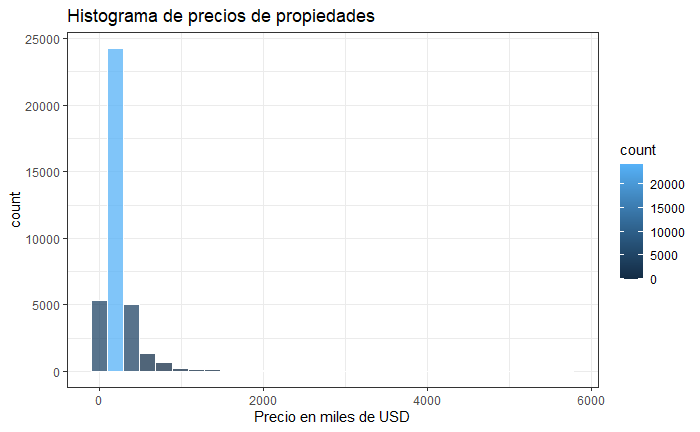

```r
# Armamos histograma de precios de las propiedades
ggplot(data = train_data, aes(x = round(price/1000))) +
  geom_histogram(col = "white", aes( fill = ..count..), alpha = 0.75) +
  labs(title = "Histograma de precios de propiedades") +
  labs(x = "Precio en miles de USD") +
  theme_bw()
```

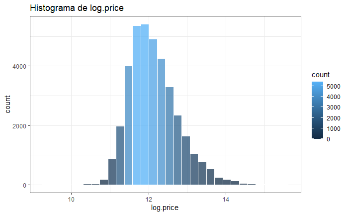

```r
# Armamos histograma de nueva variable log.price
ggplot(data = train_data, aes(x = log.price)) +
  geom_histogram(col = "white", aes( fill = ..count..), alpha = 0.75) +
  labs(title = "Histograma de log.price") +
  labs(x = "log.price") +
  theme_bw()
```

### Ajuste del modelo

Vamos a ajustar un modelo con las nuevas variables log.

```r
# modelo log
modelo_log <- lm(log.price ~ l3 + log.rooms + log.bathrooms + log.surf_cov + surface_uncovered + property_type, data = train_data)
```

```r
tidy(modelo_log, conf.int = TRUE) %>% arrange(p.value)
```

| term | estimate | std.error | statistic | p.value | conf.low | conf.high |
| --- | --- | --- | --- | --- | --- | --- |
| (Intercept) | 8.5169143684 | 0.02465291825 | 345.47286785 | 0.000000e+00 | 8.4685939691 | 8.5652347677 |
| log.bathrooms | 0.1788123881 | 0.00417760325 | 42.80262562 | 0.000000e+00 | 0.1706241705 | 0.1870006056 |
| log.surf_cov | 0.7819891353 | 0.00451268779 | 173.28677964 | 0.000000e+00 | 0.7731441428 | 0.7908341278 |
| surface_uncovered | 0.0022131580 | 0.00005042338 | 43.89150628 | 0.000000e+00 | 0.0021143268 | 0.0023119892 |
| l3Puerto Madero | 0.7250691803 | 0.01991750413 | 36.40361641 | 3.731217e-285 | 0.6860303232 | 0.7641080375 |
| property_typeDepartamento | 0.2228840906 | 0.00744124177 | 29.95253986 | 8.331265e-195 | 0.2082990517 | 0.2374691296 |
| l3Villa Lugano | -0.5411491604 | 0.02338127882 | -23.14454930 | 1.115630e-117 | -0.5869771114 | -0.4953212094 |
| l3Constitución | -0.3907354697 | 0.02277104912 | -17.15930907 | 9.580483e-66 | -0.4353673536 | -0.3461035858 |
| l3Palermo | 0.2781160753 | 0.01632552110 | 17.03566297 | 7.860685e-65 | 0.2461176039 | 0.3101145467 |
| l3Belgrano | 0.2815283847 | 0.01655404904 | 17.00661778 | 1.286009e-64 | 0.2490819923 | 0.3139747771 |

[output cut: 53 more lines]

### Interpretación de coeficientes

Los coeficientes en modelos que incluyen variables con tranformación logarítmica tienen una interpretación distinta según el caso, a saber:

- El **modelo Nivel-Nivel** representa las variables en su forma original. Es decir, la interpretación de los coeficientes en este modelo consiste en: un cambio de una unidad en X, afecta en β unidades al valor esperado de Y.
- En el **modelo Nivel-Log** esa interpretación cambia: un incremento del 1% en X está asociado a un cambio en el valor esperado de Y de 0,01*β.
- En el **modelo Log-Nivel** dicho coeficiente se conoce como la **semielasticidad** de Y respecto a X. Se interpreta como: un incremento de una unidad en X está asociado a un cambio en el valor esperado de Y de (100·β)%.
- En el **modelo Log-Log** se conoce como la elasticidad de Y respecto a X. Se interpreta como: un incremento del 1% en X está asociado a un cambio en el valor esperado de Y de β%.

Sugerimos leer la sección del libro “Introductory Econometrics: A Modern Approach” de Jeffrey Wooldrige para profundizar el entendimiento de estas interpretaciones.

Veamos cómo aplican estas interpretaciones en nuestro modelo log, con algunos ejemplos:

- El coeficiente de *log(surf_cov)* es la **elasticidad** estimada del precio respecto a la superficie cubierta. Es decir, que por cada aumento del 1% en la superficie cubierta hay un aumento de aproximadamente 0,78% en el **precio medio** de los inmuebles, dadas las demás covariables.
- El coeficiente de *surface_uncovered* representa una **semielasticidad** del precio respecto de la superficie descubierta. Este coeficiente tiene una interpretación porcentual multiplicándolo por 100: el **precio medio** del inmueble aumenta 0,22% por cada metro cuadrado adicional de superficie descubierta, dadas las demás covariables.

### Diagnóstico del modelo log

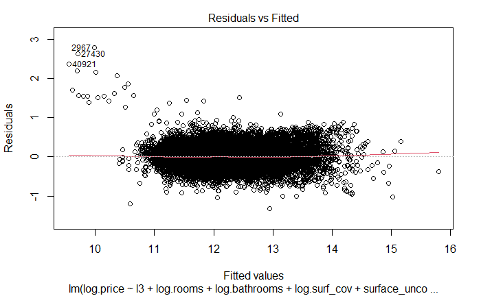

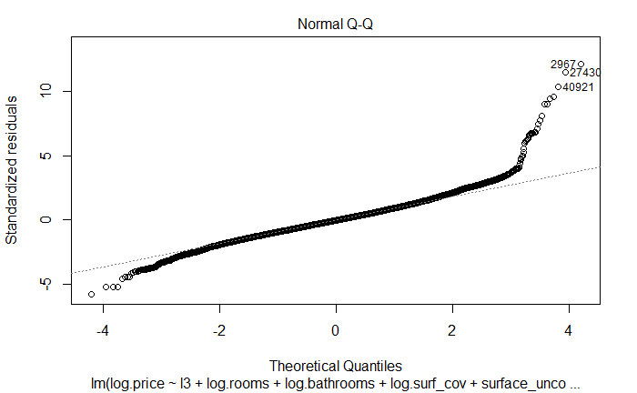

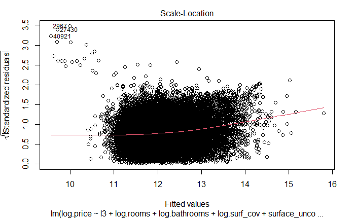

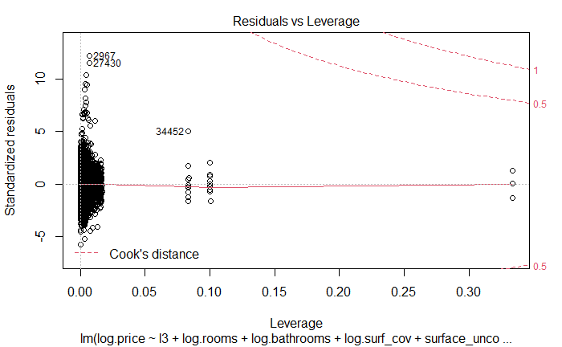

```r
plot(modelo_log)
```

- *Residuos vs valores predichos*: en este caso la distribución de residuos (y residuos estandarizados) no parece tener una forma que indique que sigue a la variable predicha (representando una mayor varianza a mayor valor predicho, como veiamos en el anterior modelo) sino que parece más bien una nube de puntos sin demasiada forma.
- *Normal QQ plot*: El extremo superior derecho no se ajusta a la distribución teórica, por lo que no parecen seguir una distribución normal.
- *Residual vs leverage*: Existen algunos puntos con alto leverage.

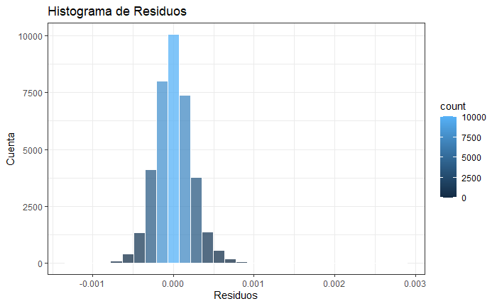

```r
eval1 <- broom::augment(modelo_log, train_data)
# grafico histograma de los residuos
g6 <- ggplot(eval1, aes(.resid/1000)) +
  geom_histogram(col = "white", aes( fill = ..count..), alpha = 0.75) +
  labs(title = "Histograma de Residuos") +
  theme(legend.position = 'none') +
  labs(y = "Cuenta") +
  labs(x = "Residuos") +
  theme_bw()
# grafico de residuos en funcion de valores predichos
g7 <-ggplot(eval1, aes(.fitted/1000, .resid/1000)) +
  geom_point(alpha = 0.5) +
  geom_hline(yintercept = 0) +
  geom_smooth(se = FALSE) +
  labs(title = "Distribución de Residuos")+
  theme(legend.position = 'none') +
  labs(y = "Residuos") +
  labs(x = "Predicción precio (miles USD)") +
  theme_bw()
# grafico de residuos estandarizados en funcion de valores predichos
g8 <- ggplot(eval1, aes(sample= .std.resid))+
  stat_qq(alpha = 0.5)+
  geom_abline(color = "blue")+
  labs(title = "QQ-plot de Residuos estandarizados")+
  theme(legend.position = 'none') +
  labs(y = "Residuos") +
  labs(x = "Cuantiles teóricos") +
  theme_bw()
# gráfico de la distribución de la raíz de residuos estandarizados
g9 <-ggplot(eval1, aes(.fitted/1000, sqrt(abs(.std.resid))))+
  geom_point(alpha = 0.5) +
  geom_smooth(se = FALSE)+
  labs(title = "Distribución Raíz de residuos estand.")+
  theme(legend.position = 'none') +
  labs(y = "Raíz Resid.estand.") +
  labs(x = "Predicción precio (miles USD)") +
  theme_bw()
# gráfico de la distribución de la raíz de residuos estandarizados
g10 <-ggplot(eval1, aes(.hat, .std.resid)) +
  geom_vline(size = 2, colour = "white", xintercept = 0) +
  geom_hline(size = 2, colour = "white", yintercept = 0) +
  geom_point(alpha = 0.7) + geom_smooth(se = FALSE) +
  labs(title = "Leverage vs. Residuos estandarizados")+
  theme(legend.position = 'none') +
  labs(y = "Resid. estand.") +
  labs(x = "Leverage (hat matrix)") +
  theme_bw()
# organizo graficos para mostrarlos juntos
g6
```

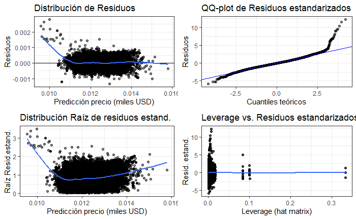

```r
grid.arrange(g7, g8, g9, g10)
```

### Evaluación y comparación de modelos

Volvemos a crear modelo varias con tipo de barrio para poder comparar con los resultados del modelo log.

```r
# Modelo varias + tipo de barrio
modelo_varias_l3 <- lm(price ~ surface_covered + surface_uncovered + rooms + property_type + l3, data = train_data)
# armamos lista con todos los modelos
models <- list(modelo_varias_l3 = modelo_varias_l3, modelo_log = modelo_log)
# calculamos las métricas para todos los modelos
df_evaluacion_train = map_df(models, broom::glance, .id = "model") %>%
  # ordenamos por R2 ajustado
  arrange(desc(adj.r.squared))
df_evaluacion_train
```

| model | r.squared | adj.r.squared | sigma | statistic | p.value | df | logLik | AIC | BIC | deviance | df.residual | nobs |
| --- | --- | --- | --- | --- | --- | --- | --- | --- | --- | --- | --- | --- |
| modelo_log | 0.8668173 | 0.8665961 | 0.2300918 | 3916.954 | 0 | 62 | 1912.98 | -3697.959 | -3152.117 | 1975.433 | 37313 | 37376 |
| modelo_varias_l3 | 0.7427481 | 0.7423276 | 114799.9600756 | 1766.139 | 0 | 61 | -488468.99 | 977063.988 | 977601.302 | 491762356516073.250 | 37314 | 37376 |

**¿Creen que se puede comparar el $R^2$ de ambos modelos? ¿Por qué?**

Una comparación de $R^2$ es significativa sólo si la variable dependiente es la misma para ambos modelos. Entonces, el $R^2$ del modelo lineal no se puede comparar con el $R^2$ del modelo log ya que en el primer caso el $R^2$ muestra la proporción de variabilidad del *precio* explicada por el modelo, mientras que en el modelo log, el $R^2$ muestra la variabilidad de *log(precio)* explicada por el modelo.

### Métricas en TRAIN

Para fines de la comparación, nos gustaría una medida que utilice el anti-log (función exponencial) del *log(precio)*. Para el modelo log, la forma de proceder es obtener los valores predichos del antilogaritmo y calcular el $R^2$ entre el antilogaritmo de los valores observados y predichos. Este $R^2$ sí será comparable con el obtenido a partir de la estimación MCO del modelo lineal.

Para ello, se puede calcular el anti-log de los valores de *log(precios)* predichos (así obtener los precios predichos), y luego computar la función `metrics()` de la librería **yardstick** con las columnas de precios predichos y observados para que devuelva: $RMSE$, $R^2$ y $MAE$. Veamos cómo hacerlo.

```r
# para ejecutar el anti-log usamos función exponencial
eval1 = eval1 %>%  mutate(fitted_antilog = exp(.fitted))
# calculamos RMSE y R2 para las variables originales y no log(price) para que sea comparable con los demás modelos
metricas1 = metrics(data = eval1, truth = price, estimate = fitted_antilog) %>% mutate(.estimate = round(.estimate, 4))
metricas1
```

| .metric | .estimator | .estimate |
| --- | --- | --- |
| rmse | standard | 102219.039 |
| rsq | standard | 0.802 |
| mae | standard | 46476.110 |

```r
# Obtenemos las metricas para el modelo sin transformaciones
eval2 <- broom::augment(modelo_varias_l3, train_data)
metricas2 = metrics(data = eval2, truth = price, estimate = .fitted) %>% mutate(.estimate = round(.estimate, 4))
metricas2
```

| .metric | .estimator | .estimate |
| --- | --- | --- |
| rmse | standard | 114704.7044 |
| rsq | standard | 0.7427 |
| mae | standard | 58334.0602 |

- Analizando el $R^2$, se observa que este modelo explica 80,2% de la variabilidad del precio, es decir, más que el modelo sin log (74,3%). De acuerdo a la literatura, y como se pudo comprobar, el uso del logaritmo de una o más variables mejora el ajuste del modelo al transformar la distribución de las características en una curva de campana de forma más normal.

### Métricas en TEST

De igual manera, obtenemos las métricas en el dataset de testing.

```r
# Obtenemos las predicciones de ambos modelos
lista_predicciones_testing = map(.x = models, .f = augment, newdata = test_data)
# Obtenemos las metricas para el modelo con transformaciones logaritmicas
metricas1_test = lista_predicciones_testing$modelo_log %>%
                 mutate(fitted_antilog= exp(.fitted)) %>%
                 metrics(truth=price, estimate=fitted_antilog) %>%
                 mutate(.estimate=round(.estimate, 4))
# Obtenemos las metricas para el modelo sin transformaciones
metricas2_test = lista_predicciones_testing$modelo_varias_l3 %>%
                 metrics(truth=price, estimate=.fitted) %>%
                 mutate(.estimate=round(.estimate, 4))
metricas1_test
```

| .metric | .estimator | .estimate |
| --- | --- | --- |
| rmse | standard | 105188.1888 |
| rsq | standard | 0.7971 |
| mae | standard | 46754.6242 |

```r
metricas2_test
```

| .metric | .estimator | .estimate |
| --- | --- | --- |
| rmse | standard | 120621.3573 |
| rsq | standard | 0.7151 |
| mae | standard | 59887.7687 |

- Observamos que el modelo_log presenta menor $RMSE$ y $MAE$ y mayor $R^2$ tanto en training como en testing. Por lo que parece ser el mejor modelo para predecir el precio.

### Notas técnicas

#### Modelo log-log: Derivación de la elasticidad

Para entender cómo surge la interpretación de un coeficiente en un modelo log-log como la **elasticidad** podemos partir de la siguiente formulación:

$$ln(Y) = \beta_0 + \beta_1X_1 +\beta_2ln(X_2)$$
Tomamos la derivada parcial respecto $X_2$ y nos queda:

$$\frac{1}{Y} \frac{\delta Y}{\delta X_2} = \beta_2 \frac{1}{X_2}$$
$$\beta_2 = \frac{X_2}{Y} \frac{\delta Y}{\delta X_2}$$

#### Caso de interacción entre una variable log y otra sin transformación

Ahora si aplicamos el mismo procedimiento para un modelo en el cual realizamos la interacción entre $X_1$ y $ln(X_2)$:

$$ln(Y) = \beta_0 + \beta_1X_1 +\beta_2ln(X_2) + \beta_3X_1.ln(X_2)$$

Tomando la derivada parcial respecto de $X_2$:

$$\frac{1}{Y} \frac{\delta Y}{\delta X_2} = \beta_2 \frac{1}{X_2} + \beta_3X_1.\frac{1}{X_2}$$
$$\frac{X_2}{Y} \frac{\delta Y}{\delta X_2} = \beta_2 + \beta_3X_1$$

Ahora nos queda que el valor de la elasticidad de $Y$ respecto de $X_2$ depende de $X_1$. Dependiendo de si $X_1$ es una variable binaria o numérica es cómo se va a poder interpretar el coeficiente $\beta_3$.

Para mayor detalle de caso de interacción entre dos variables log recomendamos ver [How to interpret interaction in Log Log models](https://stats.stackexchange.com/questions/405707/how-to-interpret-interaction-in-log-log-models). También sugerimos para el caso de variables dummies revisar [Log-Log Regression - Dummy Variable and Index](https://stats.stackexchange.com/questions/240572/log-log-regression-dummy-variable-and-index).

## Colinealidad de los Predictores

Cuando las variables predictoras están correlacionadas entre sí, decimos que existe intercorrelación o multicolinealidad.

¿Qué pasa en nuestro dataset con la superficie cubierta y descubierta?

```r
cor(train_data$surface_total, train_data$surface_covered)
```

```
[1] 0.9459646
```

Como ya habíamos visto en el gráfico ggpairs inicial, estas variables tienen alta correlación. Veamos qué ocurre con los coeficientes de ambas variables al armar distintos modelos múltiples que las incluyan.

Armamos un **modelo con superficie total, superficie cubierta, habitaciones y tipo de propiedad**.

```r
modelo_stsc_r_pt <- lm(price ~ surface_total + surface_covered + rooms + property_type, data = train_data)
tidy(modelo_stsc_r_pt)
```

| term | estimate | std.error | statistic | p.value |
| --- | --- | --- | --- | --- |
| (Intercept) | -232619.3022 | 4343.64338 | -53.55396 | 0.000000e+00 |
| surface_total | 918.0184 | 27.53199 | 33.34370 | 3.032483e-240 |
| surface_covered | 2421.2888 | 35.33752 | 68.51892 | 0.000000e+00 |
| rooms | -9105.7561 | 767.99859 | -11.85648 | 2.276886e-32 |
| property_typeDepartamento | 245065.6510 | 3930.21356 | 62.35428 | 0.000000e+00 |
| property_typePH | 136414.9676 | 4279.68610 | 31.87499 | 5.307392e-220 |

Armamos un **modelo con superficie total y cubierta**.

```r
modelo_stsc <- lm(price ~ surface_total + surface_covered, data = train_data)
tidy(modelo_stsc)
```

| term | estimate | std.error | statistic | p.value |
| --- | --- | --- | --- | --- |
| (Intercept) | 5710.3619 | 1122.17913 | 5.088637 | 3.623909e-07 |
| surface_total | 412.6293 | 28.65261 | 14.401107 | 6.801268e-47 |
| surface_covered | 2516.5283 | 35.51989 | 70.848421 | 0.000000e+00 |

Armamos un **modelo con superficie total, habitaciones y tipo de propiedad** pero sin contemplar superficie cubierta.

```r
modelo_st_r_pt <- lm(price ~ surface_total + rooms + property_type, data = train_data)
tidy(modelo_st_r_pt)
```

| term | estimate | std.error | statistic | p.value |
| --- | --- | --- | --- | --- |
| (Intercept) | -242590.713 | 4605.77325 | -52.67101 | 0.000000e+00 |
| surface_total | 2559.514 | 14.39451 | 177.81190 | 0.000000e+00 |
| rooms | 8325.418 | 768.80186 | 10.82908 | 2.751856e-27 |
| property_typeDepartamento | 248888.316 | 4169.31458 | 59.69526 | 0.000000e+00 |
| property_typePH | 114183.392 | 4527.43776 | 25.22031 | 3.514372e-139 |

##### ¿Qué diferencias encuentran con los coeficientes de superficie total y cubierta en los 3 modelos?

- Los coeficientes de regresión estimados se modifican sustancialmente cuando agregamos o quitamos variables del modelo. En el modelo que tiene las 4 variables vs. el que solo tiene las superficies cubierta y total el beta estimado de la superficie total cambia de 918 a 413 y la cubierta de 2421 a 2517 .
- Los errores estándares de los estimadores de los coeficientes aumentan espúreamente cuando se incluyen covariables muy correlacionadas. Se infla la varianza estimada de los estimadores. En nuestro caso: el error estándar de la variable superficie total en el primer modelo donde está incluida la superficie cubierta es de alrededor de 27.5, mientras que en el modelo último que se excluye dicha variable es de 14.4.

Veamos qué ocurre si en vez de usar la superficie total en el modelo último usamos la superficie cubierta.

```r
modelo_sc_r_pt <- lm(price ~ surface_covered + rooms + property_type, data = train_data)
tidy(modelo_sc_r_pt)
```

| term | estimate | std.error | statistic | p.value |
| --- | --- | --- | --- | --- |
| (Intercept) | -209936.344 | 4353.33301 | -48.22428 | 0.000000e+00 |
| surface_covered | 3446.566 | 17.67109 | 195.03987 | 0.000000e+00 |
| rooms | -8166.732 | 778.80473 | -10.48624 | 1.084880e-25 |
| property_typeDepartamento | 220725.900 | 3918.80328 | 56.32482 | 0.000000e+00 |
| property_typePH | 125349.412 | 4329.74778 | 28.95074 | 2.847875e-182 |

Observamos que otra vez cambia el valor del estimador.

Los coeficientes pueden ser no significativos aún cuando exista una asociación verdadera entre la variable de respuesta y el conjunto de regresoras cuando armamos un modelo con multicolinealidad de variables regresoras.

> Hay que tener cuidado con la colinealidad de los predictores para no tener problemas con la interpretación de los coeficientes del modelo lineal y que no aumenten espúreamente la varianza estimada de los estimadores.

### Observaciones sobre la interpretación de los coeficientes

**Modelo con superficies total y cubierta**

La interpretación de los coeficientes estimados sería:

- $\hat{\beta_{surface\_total}}$ indica que por cada m2 adicional de superficie total el precio **esperado** aumenta en 412 dólares, dada la superficie cubierta.
- $\hat{\beta_{surface\_covered}}$ indica que por cada m2 adicional de superficie cubierta el precio **esperado** aumenta en 2.516 dólares, dada la superficie total.

Respecto a la segunda interpretación alguien podría objetar lo siguiente:

$surface\_total = suface\_covered + suface\_uncovered$

Entonces, si aumento en un m2 la superficie cubierta no puedo sostener que variable superficie total se mantiene constante.

¿Es esta observación correcta?

El coeficiente de $\hat{\beta_{surface\_total}}$ en realidad nos permite evaluar cuál es el efecto en el precio esperado de un m2 más de superficie descubierta para igual cantidad de m2 de superficie cubierta. Es decir, lo que cambia es la interpretación en este caso de dicho coeficiente.

**Modelo superficies cubierta y descubierta**

Ahora nuestro modelo es:

$$E(precio|...) = \beta_0 + \beta_{sc}surface\_covered + \beta_{su}surface\_uncovered$$

Para ello, creamos una nueva variable de superficie descubierta que sea resultado de la resta entre superficie total y cubierta.

Construimos el modelo lineal que planteamos

```r
tidy(lm(price ~ surface_covered + surface_uncovered, data = train_data))
```

| term | estimate | std.error | statistic | p.value |
| --- | --- | --- | --- | --- |
| (Intercept) | 5710.3619 | 1122.17913 | 5.088637 | 3.623909e-07 |
| surface_covered | 2929.1576 | 12.53584 | 233.662596 | 0.000000e+00 |
| surface_uncovered | 412.6293 | 28.65261 | 14.401107 | 6.801268e-47 |

La interpretación de los coeficientes estimados es:

- $\hat{\beta_{suface\_covered}}$ indica que por cada m2 adicional de superficie cubierta el precio **esperado** de las propiedades aumenta en 2.929 dólares, dada la superficie descubierta.
- $\hat{\beta_{suface\_uncovered}}$ indica que por cada m2 adicional de superficie descubierta el precio **esperado** aumenta 412 dólares, dada la superficie cubierta.

En este caso la regresión ayuda a entender cómo afecta la superficie cubierta y descubierta al precio del inmueble. Es decir, cuánto aumenta el precio **medio** un m2 adicional de superficie cubierta, dada la superficie descubierta, y cuánto aumenta el precio promedio un m2 adicional de superficie descubierta, dada la superficie cubierta.